# MEDL_PS04

**Deep Learning for Mechanical Engineering**  
**Homework 04**  
**Due Wed., 10/04/2023, 4:00 PM**

Instructor: Prof. Seungchul Lee  
http://iailab.kaist.ac.kr/  
Industrial AI Lab at KAIST

- For your handwritten solution, scan or take a picture of them (you can write it in markdown if you want).
- For your code, only .ipynb file will be graded.
  - Please write your NAME and student ID on your .ipynb files. ex) IljeokKim_20202467_HW02.ipynb
- Please compress all the files to make a single .zip file
  - Please write your NAME and student ID on your .zip files. ex) DogyeomPark_20202467_HW02.zip
  - Submit it to KLMS
- Do not submit a printed version of your code. It will not be graded.

# Problem 1: Understanding Backpropagation

In this problem, we are going to compute the gradient using the chain rule and dynamic programming, and update the weights $\omega \rightarrow \omega^+$. After that, the weights are updated through 1 back-propagation and compared with the error before the update.

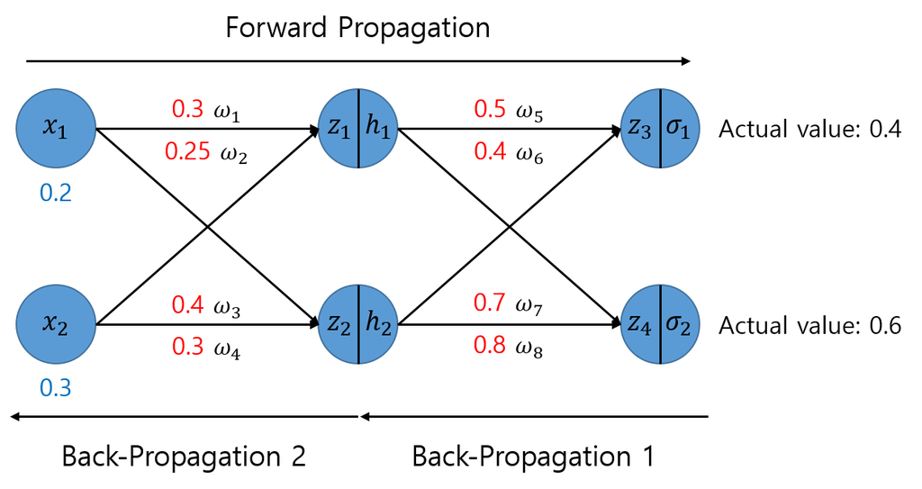

**Neural Network Model**

- The artificial neural network structure: an input layer, a hidden layern, and an output layer.
- All neurons ($h_1$, $h_2$, $\sigma_1$ and $\sigma_2$) in the hidden and output layers use the sigmoid function as activation function.
- The red number means the initial weight values, the blue number means the input values, and the ground truth means the actual values.
- The loss function is the mean square error (MSE). Use `1/2 MSE` for calculation convenience. For example, $E = \frac{1}{2}\sum(\text{target} - \text{output})^2$
- Learning rate is set to 0.9.

### Step 1: Forward Propagation

(1) [hand written] Write and calculate $z_1$, $z_2$, $h_1$, $h_2$, $z_3$, $z_4$, $\sigma_1$, $\sigma_2$, and $E_{\text{total}}$ of forward propagation.

### Step 2: BackPropagation 1

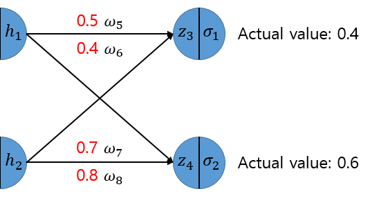

(2) [hand written] update $\omega_5$, $\omega_6$, $\omega_7$, $\omega_8$ $\rightarrow$ $\omega_5^+$, $\omega_6^+$, $\omega_7^+$, $\omega_8^+$ of back-propagation.

### Step 3: BackPropagation 2

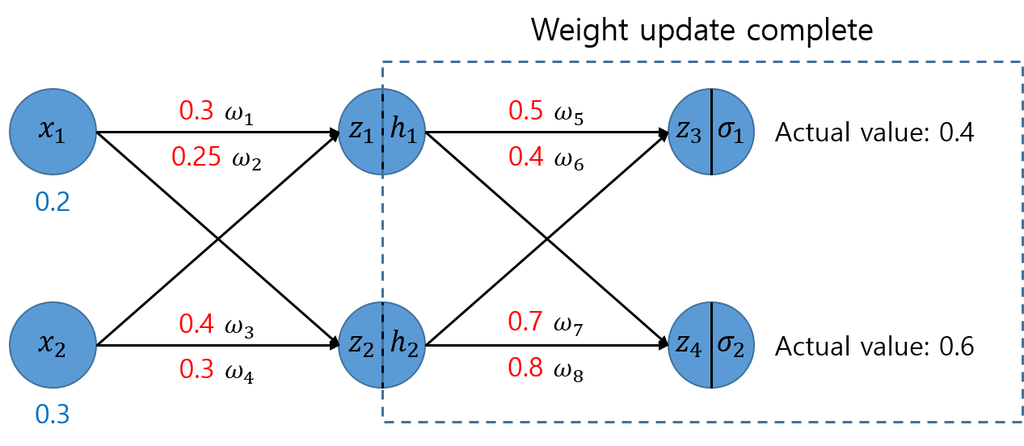

(3) [hand written] update $\omega_1$, $\omega_2$, $\omega_3$, $\omega_4$ $\rightarrow$ $\omega_1^+$, $\omega_2^+$, $\omega_3^+$, $\omega_4^+$ of back-propagation.

### Step 4: Check the Result for Weight Update

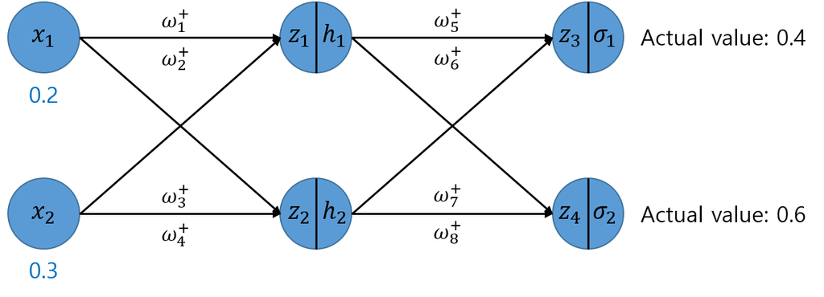

(4) [hand written] Write and calculate $E_{\text{total}}$ with the updated weights, and compare it to the previous error.